# R Notebook

Mina Almasi, Daniel Blumenkranz, Anton Drasbæk Schiønning, Matilde Sterup

27-10-2021

# Exercises and objectives

The objectives of the exercises of this assignment are based on: https://doi.org/10.1016/j.concog.2019.03.007

4. Download and organise the data from experiment 1
5. Use log-likelihood ratio tests to evaluate logistic regression models
6. Test linear hypotheses
7. Estimate psychometric functions for the Perceptual Awareness Scale and evaluate them

REMEMBER: In your report, make sure to include code that can reproduce the answers requested in the exercises below (**MAKE A KNITTED VERSION**)  
REMEMBER: This is part 2 of Assignment 2 and will be part of your final portfolio

# EXERCISE 4 - Download and organise the data from experiment 1

Go to https://osf.io/ecxsj/files/ and download the files associated with Experiment 1 (there should be 29).  
The data is associated with Experiment 1 of the article at the following DOI https://doi.org/10.1016/j.concog.2019.03.007

1. Put the data from all subjects into a single data frame - note that some of the subjects do not have the *seed* variable. For these subjects, add this variable and make in *NA* for all observations. (The *seed* variable will not be part of the analysis and is not an experimental variable)

```r
#loading data
data <- read_bulk(directory = "/Users/minaalmasi/Documents/Cognitive_Science/Methods_3/methods3_code/github_methods_3/week_05/experiment_1")
```

```
Final data.frame has 0 rows. Please check that directory was specified correctly.
```

```r
# daniblu wd
data <- read_bulk(directory = "C:/Users/mrdan/Documents/B.Sc. Cognitive Science/3. semester/Methods 3 - Multilevel Statistical Modeling and Machine Learning/Class/github_methods_3/week_05/experiment_1")
```

```
Final data.frame has 0 rows. Please check that directory was specified correctly.
```

```r
# anton wd
data <- read_bulk(directory = "/Users/antondrasbaek/Desktop/Uni/3rd Semester/Methods 3/github_methods_3/week_05/experiment_1")
```

```
Reading 001.csv
Reading 002.csv
Reading 003.csv
Reading 004.csv
Reading 005.csv
Reading 006.csv
Reading 007.csv
Reading 008.csv
Reading 009.csv
Reading 010.csv
Reading 011.csv
Reading 012.csv
Reading 013.csv
Reading 014.csv
Reading 015.csv
Reading 016.csv
Reading 017.csv
Reading 018.csv
Reading 019.csv
Reading 020.csv
Reading 021.csv
Reading 022.csv
Reading 023.csv
Reading 024.csv
Reading 025.csv
Reading 026.csv
Reading 027.csv
Reading 028.csv
Reading 029.csv
```

Investigating the seed variable:

```r
is_empty(data$seed) #checking whether the seed column is empty or NULL
```

```
[1] FALSE
```

```r
unique(data$seed) #looking at the unique values in the seed column
```

```
 [1] 93764 33409 25494 63023 21722 91366    NA 28587  3849 90992 66788 16969 30991 73521  3688
[16] 98435 25444  3733 80613 14592  4688 66410 14408 90174 24431 41191 18320 61503  4691 23300
```

Using the is_empty() function, we observe that no values in the seed column are empty. The NA’s are already inserted as seen by applying the unique() function to check for unique values. The insertion of NA’s may have something to do with the read_bulk() function and how it reads in the data.

$~$

##### i. Factorise the variables that need factorising

```r
data$trial.type <- as.factor(data$trial.type)
data$pas <- as.factor(data$pas)
data$trial <- as.factor(data$trial) #since it is not exactly continuous, and we do not expect a linear relationship
data$cue <- as.factor(data$cue)
data$task <- as.factor(data$task)
data$target.type <- as.factor(data$target.type)
data$obj.resp <- as.factor(data$obj.resp)
data$subject <- as.factor(data$subject)

ls.str(data)
```

```
cue :  Factor w/ 36 levels "0","1","2","3",..: 1 1 1 1 1 1 1 1 1 1 ...
even.digit :  int [1:25602] 8 4 2 8 6 6 6 4 4 8 ...
File :  chr [1:25602] "001.csv" "001.csv" "001.csv" "001.csv" "001.csv" "001.csv" "001.csv" "001.csv" ...
jitter.x :  num [1:25602] -0.431 -0.292 0.308 0.238 -0.427 ...
jitter.y :  num [1:25602] -0.335 -0.182 0.406 0.175 -0.221 ...
obj.resp :  Factor w/ 2 levels "e","o": 1 2 1 2 1 2 2 1 1 2 ...
odd.digit :  int [1:25602] 9 5 5 9 3 9 3 5 7 9 ...
pas :  Factor w/ 4 levels "1","2","3","4": 4 4 3 2 3 2 1 1 1 4 ...
rt.obj :  num [1:25602] 1.418 0.86 0.746 1.676 0.847 ...
rt.subj :  num [1:25602] 4.93 8.67 8.41 2.13 1.82 ...
seed :  int [1:25602] 93764 93764 93764 93764 93764 93764 93764 93764 93764 93764 ...
subject :  Factor w/ 29 levels "1","2","3","4",..: 1 1 1 1 1 1 1 1 1 1 ...
target.contrast :  num [1:25602] 0.1 0.1 0.1 0.1 0.1 0.1 0.1 0.1 0.1 0.1 ...
target.frames :  int [1:25602] 9 8 7 6 5 4 3 2 1 9 ...
target.type :  Factor w/ 2 levels "even","odd": 1 2 1 2 1 2 1 2 1 2 ...
task :  Factor w/ 3 levels "pairs","quadruplet",..: 2 2 2 2 2 2 2 2 2 2 ...
trial :  Factor w/ 864 levels "0","1","2","3",..: 1 2 3 4 5 6 7 8 9 10 ...
trial.type :  Factor w/ 2 levels "experiment","practice": 2 2 2 2 2 2 2 2 2 2 ...
```

The factorisation of variables have been made on the basis of Assignment 2 Part 1 where arguments were presented for the correct class of each variable.

$~$

##### ii. Remove the practice trials from the dataset (see the *trial.type* variable)

```r
data <- data %>% filter(trial.type!= "practice")

unique(data$trial.type) #checking whether "practice" has been filtered out
```

```
[1] experiment
Levels: experiment practice
```

$~$

##### iii. Create a *correct* variable

```r
data$correct <- ifelse(data$obj.resp == "e" & data$target.type == "even"|data$obj.resp == "o" & data$target.type == "odd", 1, 0)

data$correct <- as.factor(data$correct) #factorising correct
```

$~$

##### iv. Describe how the *target.contrast* and *target.frames* variables differ compared to the data from part 1 of this assignment

Target contrast, which is the contrast between the target and the background, is held constant across participants in this experiment, where each participant had their own target contrast in experiment 2.

Target frames, which is the amount of frames in which the target is shown (11.8 ms pr frame), was held constant at 3 frames in experiment 2, where it varies from 1 to 6 in this experiment. For this reason, *target.frames* should be a factor? *ATTENCIONE*.

```r
#data$target.frames <- as.factor(data$target.frames)
```

$~$

# EXERCISE 5 - Use log-likelihood ratio tests to evaluate logistic regression models

#### 1) Do logistic regression - *correct* as the dependent variable and *target.frames* as the independent variable. (Make sure that you understand what *target.frames* encode). Create two models - a pooled model and a partial-pooling model. The partial-pooling model should include a subject-specific intercept.

```r
#Complete pooling model
cp <- glm(correct~target.frames, data = data, family = binomial(link = logit))

#Partial pooling model
pp <- glmer(correct~target.frames + (1|subject), data = data, family = binomial(link = logit))
```

##### i. the likelihood-function for logistic regression is: $L(p)={\displaystyle\prod_{i=1}^Np^{y_i}(1-p)^{(1-y_i)}}$ (Remember the probability mass function for the Bernoulli Distribution). Create a function that calculates the likelihood.

```r
likelihood_function <- function(model, y_i){
  p <- fitted.values(model)
  y_i <- as.numeric(as.character(y_i)) #hack to go back to 0's and 1's

  likelihood <- prod((p^y_i)*((1-p)^(1-y_i)))
  return(likelihood)
}
```

##### ii. the log-likelihood-function for logistic regression is: $l(p) = {\displaystyle\sum_{i=1}^N}[y_i\ln{p}+(1-y_i)\ln{(1-p)}$. Create a function that calculates the log-likelihood

```r
log_likelihood_function <- function(model, y_i){
  p <- fitted.values(model)
  y_i <- as.numeric(as.character(y_i))

  log_likelihood <- sum(y_i*log(p)+(1-y_i)*log(1-p))
  return(log_likelihood)
}
```

##### iii. apply both functions to the pooling model you just created. Make sure that the log-likelihood matches what is returned from the *logLik* function for the pooled model. Does the likelihood-function return a value that is surprising? Why is the log-likelihood preferable when working with computers with limited precision?

```r
#applying the functions
likelihood_function(cp, data$correct)
```

```
[1] 0
```

```r
log_likelihood_function(cp, data$correct)
```

```
[1] -10865.25
```

```r
logLik(cp)
```

```
'log Lik.' -10865.25 (df=2)
```

The likelihood is so close to zero, that our computer (with limited precision) displays ‘0’ as output of the likelihood_function. This is why we calculate the log-likelihood as it results in a larger number that does not require as much computer precision to display.

$~$

##### iv. now show that the log-likelihood is a little off when applied to the partial pooling model - (the likelihood function is different for the multilevel function - see section 2.1 of https://www.researchgate.net/profile/Douglas-Bates/publication/2753537_Computational_Methods_for_Multilevel_Modelling/links/00b4953b4108d73427000000/Computational-Methods-for-Multilevel-Modelling.pdf if you are interested)

```r
log_likelihood_function(pp, data$correct)
```

```
[1] -10565.53
```

```r
logLik(pp)
```

```
'log Lik.' -10622.03 (df=3)
```

$~$

#### 2) Use log-likelihood ratio tests to argue for the addition of predictor variables, start from the null model, `glm(correct ~ 1, 'binomial', data)`, then add subject-level intercepts, then add a group-level effect of *target.frames* and finally add subject-level slopes for *target.frames*. Also assess whether or not a correlation between the subject-level slopes and the subject-level intercepts should be included.

```r
#null model
m0 <- glm(correct ~ 1, family = binomial(link = logit), data=data)

#subject level intercepts
m1 <- glmer(correct ~ 1 + (1|subject), family = binomial(link = logit), data=data)

#added group level effect of target.frames
m2 <- glmer(correct ~ 1 + target.frames + (1|subject), family = binomial(link = logit), data=data)

#without correlation between the subject-level slopes and the subject-level intercepts
m3 <- glmer(correct ~ 1 + target.frames + (1+target.frames||subject), family = binomial(link = logit), data=data)

#with correlation between the subject-level slopes and the subject-level intercepts
m4 <- glmer(correct ~ 1 + target.frames + (1+target.frames|subject), family = binomial(link = logit), data=data)

#anova
anova(m1, m2, m3, m4)
```

```
Data: data
Models:
m1: correct ~ 1 + (1 | subject)
m2: correct ~ 1 + target.frames + (1 | subject)
m3: correct ~ 1 + target.frames + (1 + target.frames || subject)
m4: correct ~ 1 + target.frames + (1 + target.frames | subject)
   npar   AIC   BIC logLik deviance    Chisq Df Pr(>Chisq)
m1    2 26319 26335 -13158    26315
m2    3 21250 21274 -10622    21244 5071.035  1  < 2.2e-16 ***
m3    4 20929 20961 -10460    20921  323.487  1  < 2.2e-16 ***
m4    5 20908 20948 -10449    20898   22.926  1  1.684e-06 ***
---
Signif. codes:  0 ‘***’ 0.001 ‘**’ 0.01 ‘*’ 0.05 ‘.’ 0.1 ‘ ’ 1
```

It seems that each model gradually performs significantly better than the previous model. The model where there is a correlation between the subject-level slopes and the subject-level intercepts (m4) performs significantly better in the anova() comparison on all parameters (p<.001) than the rest. Thus, a correlation should be included.

$~$

##### i. write a short methods section and a results section where you indicate which model you chose and the statistics relevant for that choice. Include a plot of the estimated group-level function with `xlim=c(0, 8)` that includes the estimated subject-specific functions.

$~$

**METHODS SECTION**

$~$

**Participants**: Experiment 1 was conducted on 29 participants, of whom 18 were female and 11 were male. All participants had normal or corrected to normal vision and provided informed consent to participate. This sample size was chosen since it is twice as large as the sample sizes of two previous studies central to this experiment.

$~$

**Procedure and stimuli**: Participants were asked to provide an ‘objective response’ (even or odd) to a ‘target’ (number) which was presented for 1-6 frames of 11.6 ms and followed by a mask. Before the target was presented, participants would have seen a cue (2, 4 or 8 numbers, always half even/odd) until button press. The target would always be one of the numbers that were presented in the cue. At the end of each trial, participants were asked to provide a ‘subjective response’ (on the perceptual awareness scale (pas), 1-4) of their certainty, where 1 was ‘no experience’, 2 was ‘weak glimpse’, 3 was ‘almost clear experience’ and 4 was ‘clear experience’ of the target.

$~$

**ANALYSIS**: Trying to predict *correct*, we made 4 different generalised linear mixed effects models (GLMM) and calculated the log likelihood using the anova() function. See chunk 5.2 for the code. Here follows a description of each model:

m1: This model has subject level intercepts: $\text{correct} \sim 1 + (1|\text{subject})$

m2: This model is equal to m1, but also included a group level effect of target.frames: $\text{correct} \sim 1 + \text{target.frames} + (1|\text{subject})$

m3: This model is equal to m2, but also included subject-level slopes for target.frames, without a correlation with the subject-level intercepts: $\text{correct} \sim 1 + \text{target.frames} + (1+\text{target.frames}||\text{subject})$

m4: This model is equal to m3, but also included a correlation between the subject-level slopes and the subject-level intercepts: $\text{correct} \sim 1 + \text{target.frames} + (1+\text{target.frames}|\text{subject})$

$~$

**RESULTS SECTION**

$~$

The mixed effects model that included a correlation between random slopes and intercepts (m4) was found to have the highest log-likelihood (-10449). For this reason, we choose m4 as our final model with $_0 = -1.09 (SE = 0.059, p < .001) $ & $\beta_1 = 0.83 (SE = 0.044, p < .001)$ odds ratio:

```r
tibble("Model" = c("m1", "m2", "m3", "m4"), "Log-likelihood" = c(logLik(m1), logLik(m2), logLik(m3), logLik(m4)))
```

| Model | Log-likelihood |
| --- | --- |
| m1 | -13157.55 |
| m2 | -10622.03 |
| m3 | -10460.29 |
| m4 | -10448.83 |

```r
round(m4@beta, 2)
```

```
[1] -1.09  0.83
```

The plot below shows the estimated group-level function (red line) with *target.frames* on the x-axis and also includes the estimated subject-specific functions (blue lines). The black dots are the responses made by each participant (correct or incorrect for 1-6 frames of target exposure.) There are multiple dots on top of each other, however each dot is see-through - the darker the color, the more dots.

$~$

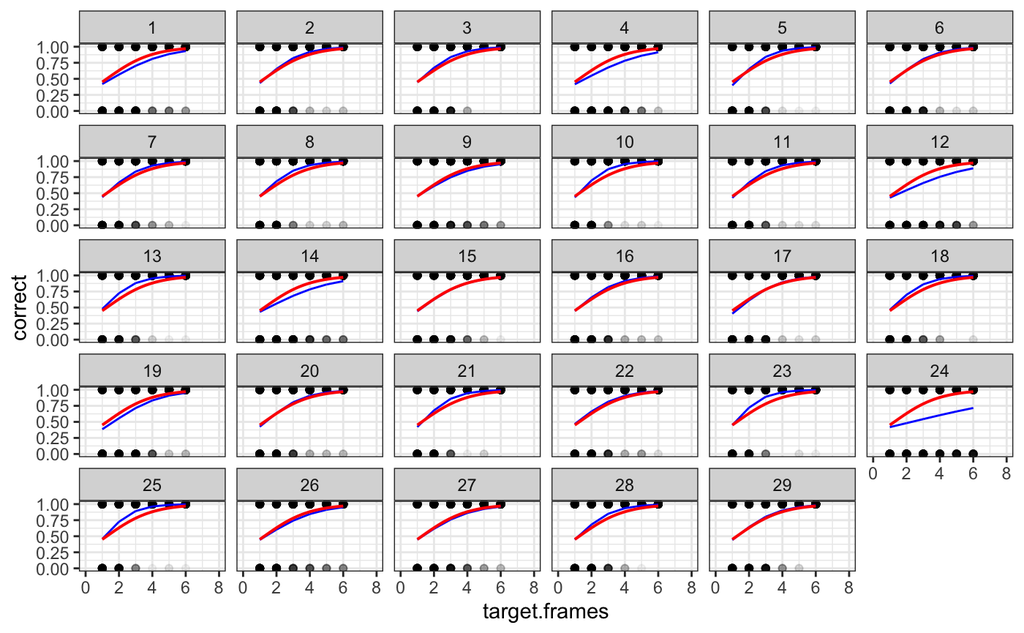

```r
fitted_values <- fitted(m4) # extract fitted values for geom_line
data2 <- data %>%
  dplyr::select(-subject) # create data without subject to override facet_wrap in plot

data2$fitted_values <- fitted_values

ggplot(data, aes(x = target.frames, y = as.numeric(as.character(correct))))+
  geom_point(aes(y=as.numeric(as.character(correct))), color = "black", alpha = 0.05)+ # add alpha to be able to better access how many dots are clumped together
  geom_line(aes(target.frames, fitted_values), color = "blue") +
  #geom_line(data = data2, aes(target.frames, fitted_values), color = "red") +
  geom_smooth(data = data2, method = "glm", se = FALSE, method.args = list(family = "binomial"), color = "red", size = 0.7) +
  facet_wrap(.~subject)+
  xlim(min = 0, max = 8)+
  labs(y = "correct") +
  theme_bw()
```

$~$

##### ii. also include in the results section whether the fit didn’t look good for any of the subjects. If so, identify those subjects in the report, and judge (no statistical test) whether their performance (accuracy) differed from that of the other subjects. Was their performance better than chance? (Use a statistical test this time) (50 %)

```r
subject24 <- data %>%
  filter(subject == 24)

t.test(x = as.numeric(as.character(subject24$correct)), mu = 0.5)
```

```
    One Sample t-test

data:  as.numeric(as.character(subject24$correct))
t = 4.026, df = 873, p-value = 6.167e-05
alternative hypothesis: true mean is not equal to 0.5
95 percent confidence interval:
 0.5345964 0.6004150
sample estimates:
mean of x
0.5675057
```

The fit suits most of the subjects well. However, the function for subject 24 deviates a lot from the group-specific function. When inspecting the accuracies, it also appears that subject 24 differed from the other subjects. From the plot, we can tell that subject 24 has many incorrect trials even with 6 target frames (indicated by the fully black dot at accuracy = 0, target.frames = 6) which is not the case for a lot of the participants. Subject 24 has a mean accuracy of 0.5675. To assess whether this performance was better than pure chance, we ran a one-sample t-test against a theoretical value of 0.5. The t-test showed that subject 24 did differ significantly from pure chance (50%), $t(873) = 4.026, p < .001$.

$~$

LINK TO REPORT (NB remove in final knit!!): https://docs.google.com/document/d/1H3XydA8hSaq9Km6MN8T78q_r6Cr46UNR67R3tC5NFwc/edit

#### 3) Now add *pas* to the group-level effects - if a log-likelihood ratio test justifies this, also add the interaction between *pas* and *target.frames* and check whether a log-likelihood ratio test justifies this

```r
m5 <- glmer(correct ~ 1 + target.frames + pas + (1+target.frames|subject), family = binomial(link = logit), data=data)
m6 <- glmer(correct ~ 1 + target.frames * pas + (1+target.frames|subject), family = binomial(link = logit), data=data)

logLiks <- tibble("Model" = c("m4", "m5", "m6"), "Log-likelihood" = c(logLik(m4), logLik(m5), logLik(m6)))

logLiks
```

| Model | Log-likelihood |
| --- | --- |
| m4 | -10448.825 |
| m5 | -9931.828 |
| m6 | -9742.039 |

Adding *pas* to the group-level effects increases the log-likelihood and it thus justified. The same is the case for the interaction between *pas* and *target.frames* and we therefore also keep that as part of the model.

$~$

##### i. if your model doesn’t converge, try a different optimizer

Our model converged.

##### ii. plot the estimated group-level functions over `xlim=c(0, 8)` for each of the four PAS-ratings - add this plot to your report (see: 5.2.i) and add a description of your chosen model. Describe how *pas* affects accuracy together with target duration if at all. Also comment on the estimated functions’ behaviour at target.frame=0 - is that behaviour reasonable?

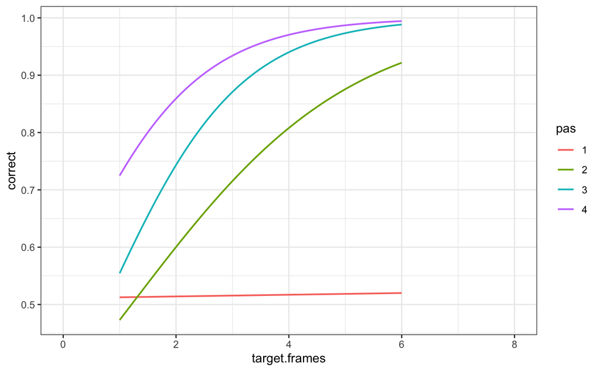

```r
ggplot(data, aes(x = target.frames, y = as.numeric(as.character(correct)), color = pas))+
  geom_smooth(method = "glm", se = FALSE, method.args = list(family = "binomial"), size = 0.7) +
  xlim(min = 0, max = 8)+
  labs(y = "correct") +
  theme_bw()
```

**CONTINUATION OF REPORT 5.2ii**: m6 includes an interaction between *pas* and *target.frames* as well as their individual effect. The plot illustrates why this interaction is meaningful to include. We can deduce that *target.frames* barely affects correctness if *pas* = 1. Contrarily, for *pas* = 2 and 3 in particular, *target.frames* affects correctness a lot. *pas* = 4 is consistently above all other levels of pas regardless of the *target.frames*, suggesting that being very sure about your answer makes you more likely to answer correctly regardless of the number of target frames. All of the 4 functions are undefined at *target.frames* = 0. This behavior is reasonable considering that you cannot show a target in 0 frames - hence this was not done in the experiment.

$~$

# EXERCISE 6 - Test linear hypotheses

In this section we are going to test different hypotheses. We assume that we have already proved that more objective evidence (longer duration of stimuli) is sufficient to increase accuracy in and of itself and that more subjective evidence (higher PAS ratings) is also sufficient to increase accuracy in and of itself.  
We want to test a hypothesis for each of the three neighbouring differences in PAS, i.e. the difference between 2 and 1, the difference between 3 and 2 and the difference between 4 and 3. More specifically, we want to test the hypothesis that accuracy increases faster with objective evidence if subjective evidence is higher at the same time, i.e. we want to test for an interaction.

#### 1) Fit a model based on the following formula: `correct ~ pas * target.frames + (target.frames | subject))`

```r
m7 <- glmer(correct ~ pas * target.frames + (1 + target.frames|subject), family = binomial(link = logit), data=data)
```

##### i. First, use `summary` (yes, you are allowed to!) to argue that accuracy increases faster with objective evidence for PAS 2 than for PAS 1.

```r
summary(m7)
```

```
Generalized linear mixed model fit by maximum likelihood (Laplace Approximation) ['glmerMod']
 Family: binomial  ( logit )
Formula: correct ~ pas * target.frames + (1 + target.frames | subject)
   Data: data

     AIC      BIC   logLik deviance df.resid
 19506.1  19595.5  -9742.0  19484.1    25033

Scaled residuals:
     Min       1Q   Median       3Q      Max
-19.0111   0.0537   0.1606   0.4849   1.4465

Random effects:
 Groups  Name          Variance Std.Dev. Corr
 subject (Intercept)   0.03698  0.1923
         target.frames 0.02058  0.1434   -0.76
Number of obs: 25044, groups:  subject, 29

Fixed effects:
                   Estimate Std. Error z value Pr(>|z|)
(Intercept)        -0.12163    0.06413  -1.897 0.057872 .
pas2               -0.57139    0.08940  -6.391 1.65e-10 ***
pas3               -0.53850    0.13959  -3.858 0.000114 ***
pas4                0.20157    0.25016   0.806 0.420377
target.frames       0.11480    0.03708   3.096 0.001960 **
pas2:target.frames  0.44718    0.03474  12.873  < 2e-16 ***
pas3:target.frames  0.74869    0.04595  16.293  < 2e-16 ***
pas4:target.frames  0.75928    0.06840  11.101  < 2e-16 ***
---
Signif. codes:  0 ‘***’ 0.001 ‘**’ 0.01 ‘*’ 0.05 ‘.’ 0.1 ‘ ’ 1

Correlation of Fixed Effects:
            (Intr) pas2   pas3   pas4   trgt.f ps2:t. ps3:t.
pas2        -0.461
pas3        -0.307  0.247
pas4        -0.174  0.121  0.091
target.frms -0.811  0.305  0.207  0.123
ps2:trgt.fr  0.481 -0.874 -0.244 -0.124 -0.428
ps3:trgt.fr  0.392 -0.278 -0.891 -0.111 -0.358  0.370
ps4:trgt.fr  0.276 -0.163 -0.121 -0.918 -0.260  0.225  0.200
```

We see that accuracy increases more steeply with objective evidence (*target.frames*) for *pas2* compared to *pas1* since the interaction estimate *pas2:target.frames* is positive (0.45) and significant. The estimates for *pas2*, *pas3* and *pas4* as shown in the output are not directly interpretable since these are accuracy for *target.frames* = 0. However, the lowest possible amount of target frames is 1.

2. `summary` won’t allow you to test whether accuracy increases faster with objective evidence for PAS 3 than for PAS 2 (unless you use `relevel`, which you are not allowed to in this exercise). Instead, we’ll be using the function `glht` from the `multcomp` package
   1. To redo the test in 6.1.i, you can create a *contrast* vector. This vector will have the length of the number of estimated group-level effects and any specific contrast you can think of can be specified using this. For redoing the test from 6.1.i, the code snippet below will do

```r
## testing whether PAS 2 is different from PAS 1
contrast.vector <- matrix(c(0, 0, 0, 0, 0, 1, 0, 0), nrow=1)
gh <- glht(m7, contrast.vector)
print(summary(gh))
```

```
     Simultaneous Tests for General Linear Hypotheses

Fit: glmer(formula = correct ~ pas * target.frames + (1 + target.frames |
    subject), data = data, family = binomial(link = logit))

Linear Hypotheses:
       Estimate Std. Error z value Pr(>|z|)
1 == 0  0.44718    0.03474   12.87   <2e-16 ***
---
Signif. codes:  0 ‘***’ 0.001 ‘**’ 0.01 ‘*’ 0.05 ‘.’ 0.1 ‘ ’ 1
(Adjusted p values reported -- single-step method)
```

```r
## as another example, we could also test whether there is a difference in
## intercepts between PAS 2 and PAS 3
contrast.vector <- matrix(c(0, -1, 1, 0, 0, 0, 0, 0), nrow=1)
gh <- glht(m7, contrast.vector)
print(summary(gh))
```

```
     Simultaneous Tests for General Linear Hypotheses

Fit: glmer(formula = correct ~ pas * target.frames + (1 + target.frames |
    subject), data = data, family = binomial(link = logit))

Linear Hypotheses:
       Estimate Std. Error z value Pr(>|z|)
1 == 0   0.0329     0.1459   0.225    0.822
(Adjusted p values reported -- single-step method)
```

```
ii. Now test the hypothesis that accuracy increases faster with objective evidence for PAS 3 than for PAS 2.
```

```r
contrast.vector <- matrix(c(0, 0, 0, 0, 0, -1, 1, 0), nrow=1)
gh <- glht(m7, contrast.vector)
print(summary(gh))
```

```
     Simultaneous Tests for General Linear Hypotheses

Fit: glmer(formula = correct ~ pas * target.frames + (1 + target.frames |
    subject), data = data, family = binomial(link = logit))

Linear Hypotheses:
       Estimate Std. Error z value Pr(>|z|)
1 == 0  0.30151    0.04624   6.521 6.98e-11 ***
---
Signif. codes:  0 ‘***’ 0.001 ‘**’ 0.01 ‘*’ 0.05 ‘.’ 0.1 ‘ ’ 1
(Adjusted p values reported -- single-step method)
```

```
iii. Also test the hypothesis that accuracy increases faster with objective evidence for PAS 4 than for PAS 3
```

3. Finally, test that whether the difference between PAS 2 and 1 (tested in 6.1.i) is greater than the difference between PAS 4 and 3 (tested in 6.2.iii)

```r
contrast.vector <- rbind(c(0, 0, 0, 0, 0, 1, 0, 0),
                         c(0, 0, 0, 0, 0, 0, -1, 1)
                         )

rownames(contrast.vector) <- c("Pas1-2", "Pas3-4")
gh <- glht(m7, contrast.vector)
print(summary(gh))
```

```
     Simultaneous Tests for General Linear Hypotheses

Fit: glmer(formula = correct ~ pas * target.frames + (1 + target.frames |
    subject), data = data, family = binomial(link = logit))

Linear Hypotheses:
            Estimate Std. Error z value Pr(>|z|)
Pas1-2 == 0  0.44718    0.03474  12.873   <1e-10 ***
Pas3-4 == 0  0.01059    0.07438   0.142    0.987
---
Signif. codes:  0 ‘***’ 0.001 ‘**’ 0.01 ‘*’ 0.05 ‘.’ 0.1 ‘ ’ 1
(Adjusted p values reported -- single-step method)
```

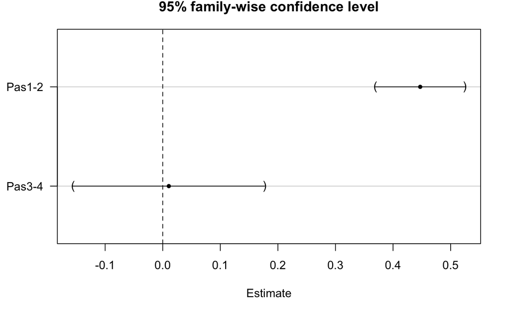

```r
plot(gh, xlab = "Estimate")
```